# mod9_mcspadden_diana

Diana McSpadden

4/13/2021

# Module 9 Homework

## H. Diana McSpadden (hdm5s)

# Question 7

In this problem, you will use support vector approaches in order to predict whether a given car gets high or low gas mileage based on the Auto data set.

```r
library(ISLR)
library(tidyverse)
auto = ISLR::Auto

head(auto)
```

```
##   mpg cylinders displacement horsepower weight acceleration year origin
## 1  18         8          307        130   3504         12.0   70      1
## 2  15         8          350        165   3693         11.5   70      1
## 3  18         8          318        150   3436         11.0   70      1
## 4  16         8          304        150   3433         12.0   70      1
## 5  17         8          302        140   3449         10.5   70      1
## 6  15         8          429        198   4341         10.0   70      1
##                        name
## 1 chevrolet chevelle malibu
## 2         buick skylark 320
## 3        plymouth satellite
## 4             amc rebel sst
## 5               ford torino
## 6          ford galaxie 500
```

## (a) Create a binary variable …

that takes on a 1 for cars with gas mileage above the median, and a 0 for cars with gas mileage below the median.

**First:** I remove the name and the mpg columns.

```r
#print(median(auto$mpg))
auto = auto %>% mutate(aboveMedian = ifelse(mpg > median(mpg), 1, 0) %>% factor(), origin = factor(origin)) %>% select(-name) %>% select(-mpg)

head(auto)
```

```
##   cylinders displacement horsepower weight acceleration year origin aboveMedian
## 1         8          307        130   3504         12.0   70      1           0
## 2         8          350        165   3693         11.5   70      1           0
## 3         8          318        150   3436         11.0   70      1           0
## 4         8          304        150   3433         12.0   70      1           0
## 5         8          302        140   3449         10.5   70      1           0
## 6         8          429        198   4341         10.0   70      1           0
```

## (b) Fit a support vector classifier to the data …

with various values of cost, in order to predict whether a car gets high or low gas mileage. Report the cross-validation errors associated with different values of this parameter. Comment on your results.

```r
library(e1071)
```

A linear kernel == a support vector classifier.

```r
set.seed(1976)

svm_tuned = tune(svm, aboveMedian~., data=auto, kernel="linear", ranges=list(cost=c(0.001, 0.01, 0.1, 1)))

summary(svm_tuned)
```

```
##
## Parameter tuning of 'svm':
##
## - sampling method: 10-fold cross validation
##
## - best parameters:
##  cost
##     1
##
## - best performance: 0.08435897
##
## - Detailed performance results:
##    cost      error dispersion
## 1 0.001 0.17346154 0.05500068
## 2 0.010 0.08673077 0.05153255
## 3 0.100 0.09442308 0.05279642
## 4 1.000 0.08435897 0.04041931
```

**Answer Q7b**: The best cost was 1, with an error rate of ~0.084.

## (c) Now repeat (b), this time using SVMs with radial and polynomial basis kernels,

with different values of gamma and degree and cost. Comment on your results.

First, I will try the radial models with different combinations of cost and gamma:

```r
set.seed(1976)

svm_multi_tuned = tune(svm, aboveMedian~., data=auto, kernel="radial", ranges=list(cost=c(0.1,1,10,100),gamma=c(0.1,0.5,1,2)))

summary(svm_multi_tuned)
```

```
##
## Parameter tuning of 'svm':
##
## - sampling method: 10-fold cross validation
##
## - best parameters:
##  cost gamma
##     1     1
##
## - best performance: 0.07660256
##
## - Detailed performance results:
##     cost gamma      error dispersion
## 1    0.1   0.1 0.08673077 0.05153255
## 2    1.0   0.1 0.08416667 0.04985007
## 3   10.0   0.1 0.08429487 0.03427773
## 4  100.0   0.1 0.08935897 0.04567674
## 5    0.1   0.5 0.08416667 0.04836245
## 6    1.0   0.5 0.08929487 0.03849957
## 7   10.0   0.5 0.08679487 0.04957283
## 8  100.0   0.5 0.09967949 0.04066711
## 9    0.1   1.0 0.08929487 0.04719277
## 10   1.0   1.0 0.07660256 0.03409074
## 11  10.0   1.0 0.08173077 0.03932001
## 12 100.0   1.0 0.08666667 0.03801354
## 13   0.1   2.0 0.13525641 0.08139651
## 14   1.0   2.0 0.08679487 0.04021093
## 15  10.0   2.0 0.08666667 0.05357226
## 16 100.0   2.0 0.09429487 0.04614044
```

The best performing radial model had cost == 1, and gamma == 1, with an error rate of ~0.077.

```r
set.seed(1976)

svm_poly_tuned = tune(svm, aboveMedian~., data=auto, kernel="polynomial", ranges=list(cost=c(0.1,1,10),gamma=c(0.5,1), degree=c(3,4)))

summary(svm_poly_tuned)
```

```
##
## Parameter tuning of 'svm':
##
## - sampling method: 10-fold cross validation
##
## - best parameters:
##  cost gamma degree
##   0.1   0.5      3
##
## - best performance: 0.07903846
##
## - Detailed performance results:
##    cost gamma degree      error dispersion
## 1   0.1   0.5      3 0.07903846 0.03260217
## 2   1.0   0.5      3 0.08173077 0.04801492
## 3  10.0   0.5      3 0.09698718 0.04449378
## 4   0.1   1.0      3 0.07916667 0.04259298
## 5   1.0   1.0      3 0.09698718 0.04449378
## 6  10.0   1.0      3 0.12512821 0.05564572
## 7   0.1   0.5      4 0.10467949 0.03534120
## 8   1.0   0.5      4 0.10980769 0.04388834
## 9  10.0   0.5      4 0.10724359 0.04155206
## 10  0.1   1.0      4 0.10730769 0.04671255
## 11  1.0   1.0      4 0.12006410 0.03851854
## 12 10.0   1.0      4 0.13262821 0.03710629
```

The best performing polynomial model had cost == 0.1, gamma == 0.5, degree of 3, with an error rate of ~0.079.

**Comments Q7c:** The radial model performed better than the polynomial model, leading me to believe that the relationship of the training data is NOT best represented with a linear or polynomial model, but needs the flexibility of a radial model.

## (d) Make some plots to back up your assertions in (b) and (c).

```r
#?plot.svm

head(auto)
```

```
##   cylinders displacement horsepower weight acceleration year origin aboveMedian
## 1         8          307        130   3504         12.0   70      1           0
## 2         8          350        165   3693         11.5   70      1           0
## 3         8          318        150   3436         11.0   70      1           0
## 4         8          304        150   3433         12.0   70      1           0
## 5         8          302        140   3449         10.5   70      1           0
## 6         8          429        198   4341         10.0   70      1           0
```

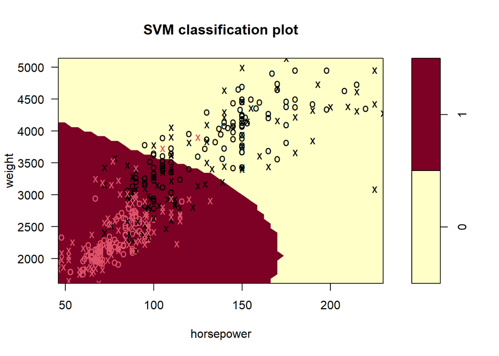

```r
best_svm_model = svm(aboveMedian~., data=auto, type="C-classification", kernel="radial", cost=1, gamma=1)


plot(best_svm_model, auto, weight ~ horsepower,
     slice = list(cylinders = median(auto$cylinders),
                  displacement = median(auto$displacement),
                  acceleration = median(auto$acceleration),
                  year = median(auto$year),
                  origin = 1))
```

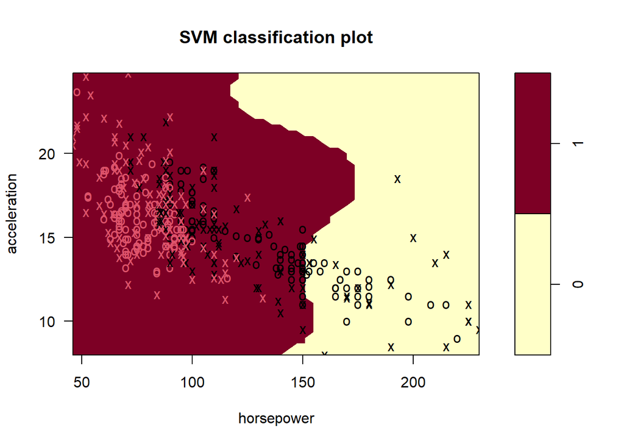

```r
plot(best_svm_model, auto, acceleration ~ horsepower,
     slice = list(weight = median(auto$weight),
                  displacement = median(auto$displacement),
                  cylinders = median(auto$cylinders),
                  year = median(auto$year),
                  origin = 1))
```

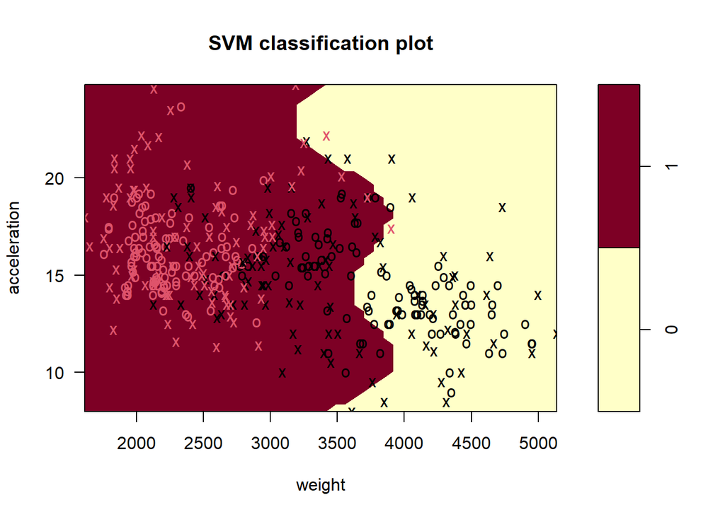

```r
plot(best_svm_model, auto, acceleration ~ weight,
     slice = list(horsepower = median(auto$horsepower),
                  displacement = median(auto$displacement),
                  cylinders = median(auto$cylinders),
                  year = median(auto$year),
                  origin = 1))
```

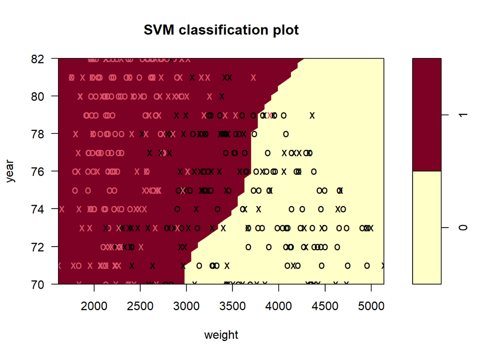

```r
plot(best_svm_model, auto, year ~ weight,
     slice = list(horsepower = median(auto$horsepower),
                  displacement = median(auto$displacement),
                  cylinders = median(auto$cylinders),
                  acceleration = median(auto$acceleration),
                  origin = 1))
```

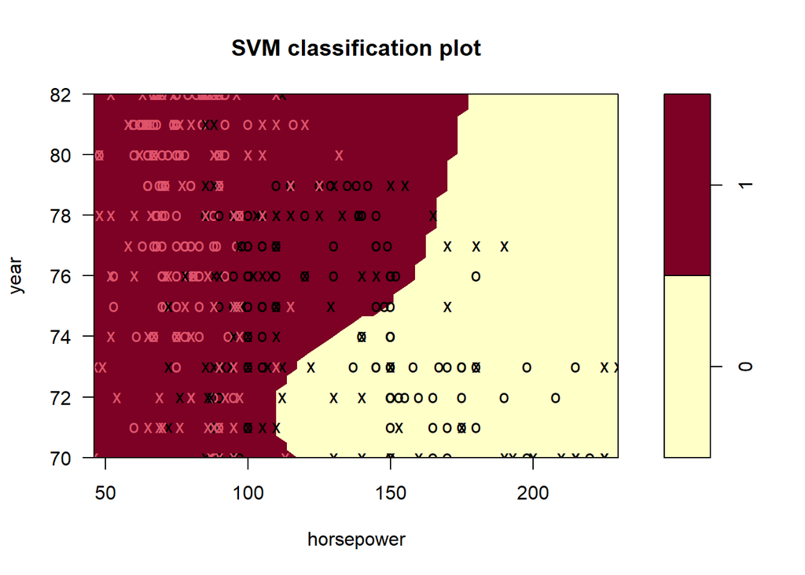

```r
plot(best_svm_model, auto, year ~ horsepower,
     slice = list(weight = median(auto$weight),
                  displacement = median(auto$displacement),
                  cylinders = median(auto$cylinders),
                  acceleration = median(auto$acceleration),
                  origin = 1))
```

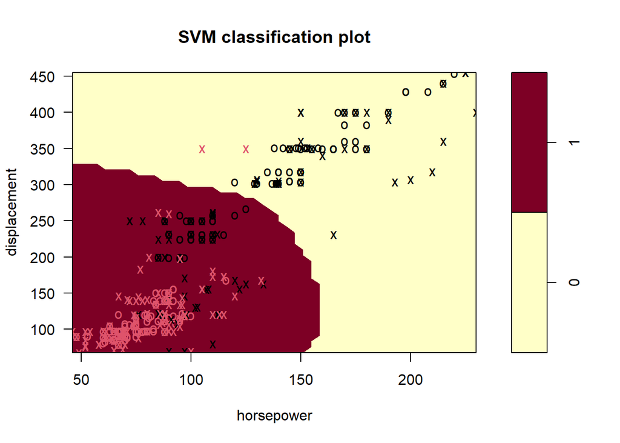

```r
plot(best_svm_model, auto, displacement ~ horsepower,
     slice = list(cylinders = median(auto$cylinders),
                  weight = median(auto$weight),
                  acceleration = median(auto$acceleration),
                  year = median(auto$year),
                  origin = 1))
```

I plotted the SVM boundary by:

- weight ~ horsepower
- acceleration ~ horsepower
- acceleration ~ weight
- year ~ weigh
- year ~ horsepower
- displacement ~ horsepower

There are a large number of support vectors in each plot.

In the plots:

- X == support vector == wrong side of margin
- 0 == doesn’t affect the divider (you can’t drop these and get the same value, but they are on correct side of margin), these points have loss of zero.
- color of X, 0 == true label

# QUestion 8

This problem involves the OJ data set which is part of the ISLR package.

## (a) Create a training set containing a random sample …

of 800 observations, and a test set containing the remaining observations.

```r
oj = ISLR::OJ

oj = oj %>% mutate(Purchase = factor(Purchase), StoreID = factor(StoreID), SpecialCH = factor(SpecialCH), SpecialMM = factor(SpecialMM), Store7 = factor(Store7), STORE = factor(STORE))

head(oj)
```

```
##   Purchase WeekofPurchase StoreID PriceCH PriceMM DiscCH DiscMM SpecialCH
## 1       CH            237       1    1.75    1.99   0.00    0.0         0
## 2       CH            239       1    1.75    1.99   0.00    0.3         0
## 3       CH            245       1    1.86    2.09   0.17    0.0         0
## 4       MM            227       1    1.69    1.69   0.00    0.0         0
## 5       CH            228       7    1.69    1.69   0.00    0.0         0
## 6       CH            230       7    1.69    1.99   0.00    0.0         0
##   SpecialMM  LoyalCH SalePriceMM SalePriceCH PriceDiff Store7 PctDiscMM
## 1         0 0.500000        1.99        1.75      0.24     No  0.000000
## 2         1 0.600000        1.69        1.75     -0.06     No  0.150754
## 3         0 0.680000        2.09        1.69      0.40     No  0.000000
## 4         0 0.400000        1.69        1.69      0.00     No  0.000000
## 5         0 0.956535        1.69        1.69      0.00    Yes  0.000000
## 6         1 0.965228        1.99        1.69      0.30    Yes  0.000000
##   PctDiscCH ListPriceDiff STORE
## 1  0.000000          0.24     1
## 2  0.000000          0.24     1
## 3  0.091398          0.23     1
## 4  0.000000          0.00     1
## 5  0.000000          0.00     0
## 6  0.000000          0.30     0
```

```r
dim(oj)
```

```
## [1] 1070   18
```

```r
set.seed(1976)
train = sample(nrow(oj), 870)

oj_train = oj[train,]
oj_test = oj[-train,]
```

## (b) Fit a support vector classifier …

to the training data using cost=0.01, with Purchase as the response and the other variables as predictors. Use the summary() function to produce summary statistics, and describe the results obtained.

```r
set.seed(1976)

q8b_svm = svm(Purchase~., data=oj_train, kernel="linear", cost=c(0.01))

summary(q8b_svm)
```

```
##
## Call:
## svm(formula = Purchase ~ ., data = oj_train, kernel = "linear", cost = c(0.01))
##
##
## Parameters:
##    SVM-Type:  C-classification
##  SVM-Kernel:  linear
##        cost:  0.01
##
## Number of Support Vectors:  468
##
##  ( 235 233 )
##
##
## Number of Classes:  2
##
## Levels:
##  CH MM
```

With what seems a relatively small cost (0.01), with a linear kernel, 468 observations of the 870 observations are support vectors. This seems high.

## (c) What are the training and test error rates?

```r
set.seed(1976)

q8b_tuned_svm = tune(svm, Purchase~., data=oj_train, kernel="linear", ranges=list(cost=c(0.01)))

summary(q8b_tuned_svm)
```

```
##
## Error estimation of 'svm' using 10-fold cross validation: 0.1747126
```

```r
pred = predict(q8b_tuned_svm$best.model, newdata = oj_test)

length(pred)
```

```
## [1] 200
```

```r
table(true = oj_test$Purchase, pred)
```

```
##     pred
## true  CH  MM
##   CH 111  11
##   MM  24  54
```

The cross validation error on the training data is **0.1747**.

The error rate of the test data is: ((24 + 11) / 200) == **0.175**

## (d) Use the tune() function …

to select an optimal cost. Consider values in the range 0.01 to 10.

```r
set.seed(1976)
q8d_tuned_svm = tune(svm, Purchase~., data=oj_train, kernel="linear", ranges=list(cost=c(0.01,0.1,1,10)))

summary(q8d_tuned_svm)
```

```
##
## Parameter tuning of 'svm':
##
## - sampling method: 10-fold cross validation
##
## - best parameters:
##  cost
##    10
##
## - best performance: 0.1678161
##
## - Detailed performance results:
##    cost     error dispersion
## 1  0.01 0.1747126 0.04461587
## 2  0.10 0.1701149 0.05106002
## 3  1.00 0.1689655 0.04847917
## 4 10.00 0.1678161 0.04375204
```

**Answer Q8d:** The optimal cost with cross validation is **10**.

## (e) Compute the training and test error rates using this new value for cost.

```r
set.seed(1976)
q8e_tuned_svm = tune(svm, Purchase~., data=oj_train, kernel="linear", ranges=list(cost=c(0.01,0.1,1,10)))

summary(q8e_tuned_svm)
```

```
##
## Parameter tuning of 'svm':
##
## - sampling method: 10-fold cross validation
##
## - best parameters:
##  cost
##    10
##
## - best performance: 0.1678161
##
## - Detailed performance results:
##    cost     error dispersion
## 1  0.01 0.1747126 0.04461587
## 2  0.10 0.1701149 0.05106002
## 3  1.00 0.1689655 0.04847917
## 4 10.00 0.1678161 0.04375204
```

```r
pred = predict(q8e_tuned_svm$best.model, newdata = oj_test)

length(pred)
```

```
## [1] 200
```

```r
table(true = oj_test$Purchase, pred)
```

```
##     pred
## true  CH  MM
##   CH 109  13
##   MM  24  54
```

**Answer Q8 e:**

The best cost **training** error rate is **0.168**.

## (f) Repeat parts (b) through (e) using a support vector machine with a radial kernel. Use the default value for gamma.

```r
print("Cost == 0.01")
```

```
## [1] "Cost == 0.01"
```

```r
set.seed(1976)
q8f_tuned_svm_01 = tune(svm, Purchase~., data=oj_train, kernel="radial", ranges=list(cost=c(0.01)))
summary(q8f_tuned_svm_01)
```

```
##
## Error estimation of 'svm' using 10-fold cross validation: 0.3896552
```

```r
pred = predict(q8f_tuned_svm_01$best.model, newdata = oj_test)
length(pred)
```

```
## [1] 200
```

```r
table(true = oj_test$Purchase, pred)
```

```
##     pred
## true  CH  MM
##   CH 122   0
##   MM  78   0
```

```r
print("Tuning COsts")
```

```
## [1] "Tuning COsts"
```

```r
set.seed(1976)
q8f_tuned_svm_costs = tune(svm, Purchase~., data=oj_train, kernel="radial", ranges=list(cost=c(0.01,0.1,1,10)))
summary(q8f_tuned_svm_costs)
```

```
##
## Parameter tuning of 'svm':
##
## - sampling method: 10-fold cross validation
##
## - best parameters:
##  cost
##     1
##
## - best performance: 0.1678161
##
## - Detailed performance results:
##    cost     error dispersion
## 1  0.01 0.3896552 0.05430621
## 2  0.10 0.1747126 0.02587271
## 3  1.00 0.1678161 0.02553001
## 4 10.00 0.1804598 0.03794845
```

```r
pred = predict(q8f_tuned_svm_costs$best.model, newdata = oj_test)
length(pred)
```

```
## [1] 200
```

```r
table(true = oj_test$Purchase, pred)
```

```
##     pred
## true  CH  MM
##   CH 110  12
##   MM  27  51
```

**Answer Q8f:**

**Using A Radial Kernel**

When using cost == **0.01**, the cross validation error rate on the training data is **0.39**, and the test error rate is 78 / 200 == **0.39**.

## (g) Repeat parts (b) through (e) using a support vector machine …

with a polynomial kernel. Set degree=2.

```r
#set.seed(1976)

#svm_poly_tuned = tune(svm, aboveMedian~., data=auto, kernel="polynomial", ranges=list(cost=c(0.1,1,10),gamma=c(0.5,1), degree=c(3,4)))


print("Cost == 0.01")
```

```
## [1] "Cost == 0.01"
```

```r
set.seed(1976)
q8g_tuned_svm_01 = tune(svm, Purchase~., data=oj_train, kernel="polynomial", ranges=list(cost=c(0.01), degree=c(2)))
summary(q8g_tuned_svm_01)
```

```
##
## Error estimation of 'svm' using 10-fold cross validation: 0.3896552
```

```r
pred = predict(q8g_tuned_svm_01$best.model, newdata = oj_test)
length(pred)
```

```
## [1] 200
```

```r
table(true = oj_test$Purchase, pred)
```

```
##     pred
## true  CH  MM
##   CH 122   0
##   MM  78   0
```

```r
print("Tuning COsts")
```

```
## [1] "Tuning COsts"
```

```r
set.seed(1976)
q8g_tuned_svm_costs = tune(svm, Purchase~., data=oj_train, kernel="polynomial", ranges=list(cost=c(0.01,0.1,1,10), degree=c(2)))
summary(q8g_tuned_svm_costs)
```

```
##
## Parameter tuning of 'svm':
##
## - sampling method: 10-fold cross validation
##
## - best parameters:
##  cost degree
##    10      2
##
## - best performance: 0.1816092
##
## - Detailed performance results:
##    cost degree     error dispersion
## 1  0.01      2 0.3896552 0.05430621
## 2  0.10      2 0.3436782 0.04890126
## 3  1.00      2 0.2011494 0.01556329
## 4 10.00      2 0.1816092 0.03375129
```

```r
pred = predict(q8g_tuned_svm_costs$best.model, newdata = oj_test)
length(pred)
```

```
## [1] 200
```

```r
table(true = oj_test$Purchase, pred)
```

```
##     pred
## true  CH  MM
##   CH 110  12
##   MM  29  49
```

**Answer Q8g:**

**Using A Polynomial Kernel of Degree 2**

When using cost == **0.01**, the cross validation error rate on the training data is **0.39**, and the test error rate is 78 / 200 == **0.39**.

When tuning for cost, the best cost is **10**, and the training error rate is **0.18**, and the test error rate is (29 + 12) / 200 == **0.205**.

## (h) Overall, which approach …

seems to give the best results on this data?